# Descriptive Statistics 1: Introduction to Statistics & Describing Data

# Load Packages

```r
# Load packages - we use pload form pacman, loads them and installs. tidyverse data manip, here for file paths, janitor tabyls, inspect and vis for data exploration.
pacman::p_load(tidyverse,
               here,
               janitor,
               inspectdf,
               visdat)
```

# The Yaounde COVID-19 dataset

```r
# Import data to RStudio (live type?)
yaounde <- read_csv(here("data/yaounde_data.csv"))
```

```r
spec(yaounde)
```

[output not shown]

- Let’s spend some time browsing through this dataset.

```r
# View first 6 rows of the dataframe
head(yaounde)
```

```
# A tibble: 6 × 53
  id     date_surveyed   age age_category age_category_3 sex   highest_education
  <chr>  <date>        <dbl> <chr>        <chr>          <chr> <chr>
1 BRIQU… 2020-10-22       45 45 - 64      Adult          Fema… Secondary
2 BRIQU… 2020-10-24       55 45 - 64      Adult          Male  University
3 BRIQU… 2020-10-24       23 15 - 29      Adult          Male  University
4 BRIQU… 2020-10-22       20 15 - 29      Adult          Fema… Secondary
5 BRIQU… 2020-10-22       55 45 - 64      Adult          Fema… Primary
6 BRIQU… 2020-10-25       17 15 - 29      Child          Fema… Secondary
# ℹ 46 more variables: occupation <chr>, weight_kg <dbl>, height_cm <dbl>,
#   is_smoker <chr>, is_pregnant <chr>, is_medicated <chr>, neighborhood <chr>,
#   household_with_children <chr>, breadwinner <chr>, source_of_revenue <chr>,
#   has_contact_covid <chr>, igg_result <chr>, igm_result <chr>,
#   symptoms <chr>, symp_fever <chr>, symp_headache <chr>, symp_cough <chr>,
#   symp_rhinitis <chr>, symp_sneezing <chr>, symp_fatigue <chr>,
#   symp_muscle_pain <chr>, symp_nausea_or_vomiting <chr>, …
```

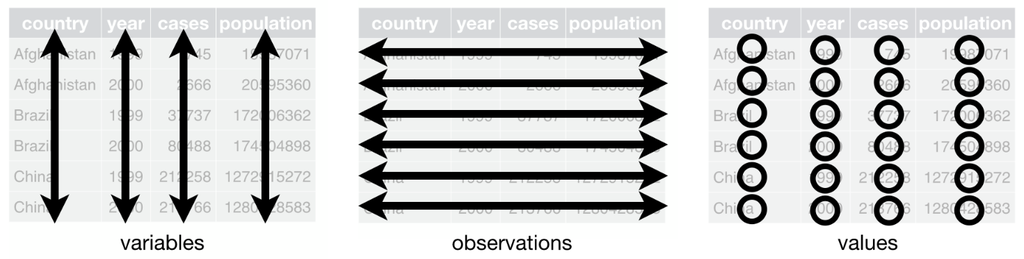

- Each row corresponds to one patient surveyed.
- There are some demographic, socio-economic and COVID-related variables.
- The results of the IgG and IgM antibody tests are in the columns `igg_result` and `igm_result`.

```r
# View variable data classes
glimpse(yaounde)
```

```
Rows: 971
Columns: 53
$ id                        <chr> "BRIQUETERIE_000_0001", "BRIQUETERIE_000_000…
$ date_surveyed             <date> 2020-10-22, 2020-10-24, 2020-10-24, 2020-10…
$ age                       <dbl> 45, 55, 23, 20, 55, 17, 13, 28, 30, 13, 62, …
$ age_category              <chr> "45 - 64", "45 - 64", "15 - 29", "15 - 29", …
$ age_category_3            <chr> "Adult", "Adult", "Adult", "Adult", "Adult",…
$ sex                       <chr> "Female", "Male", "Male", "Female", "Female"…
$ highest_education         <chr> "Secondary", "University", "University", "Se…
$ occupation                <chr> "Informal worker", "Salaried worker", "Stude…
$ weight_kg                 <dbl> 95, 96, 74, 70, 67, 65, 65, 62, 73, 56, 53, …
$ height_cm                 <dbl> 169, 185, 180, 164, 147, 162, 150, 173, 170,…
$ is_smoker                 <chr> "Non-smoker", "Ex-smoker", "Smoker", "Non-sm…
$ is_pregnant               <chr> "No", NA, NA, "No", "No", "No", "No", NA, NA…
$ is_medicated              <chr> "Yes", "No", "Yes", "No", "No", "No", "No", …
```

[output cut: 40 more lines]

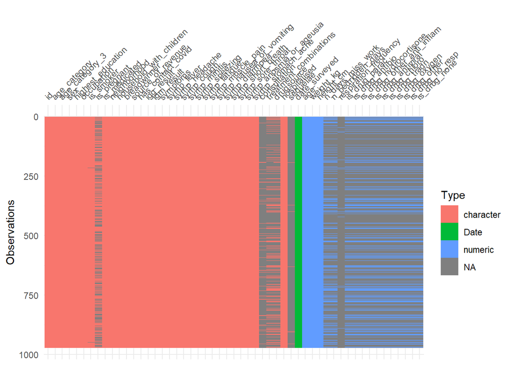

```r
# VISUALIZE DATA TYPE OF EACH VARIABLE

vis_dat(yaounde)
```

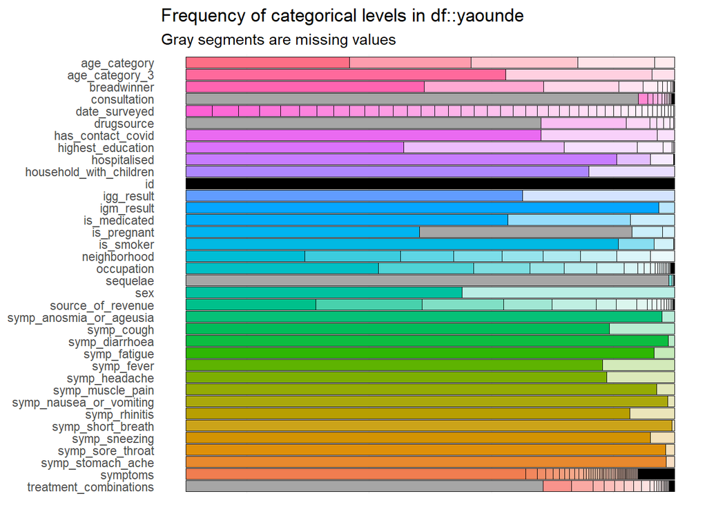

```r
# INSPECT CATEGOTIRICAL VARIABLES

yao_cat_summary <- inspect_cat(yaounde)


show_plot(yao_cat_summary)
```

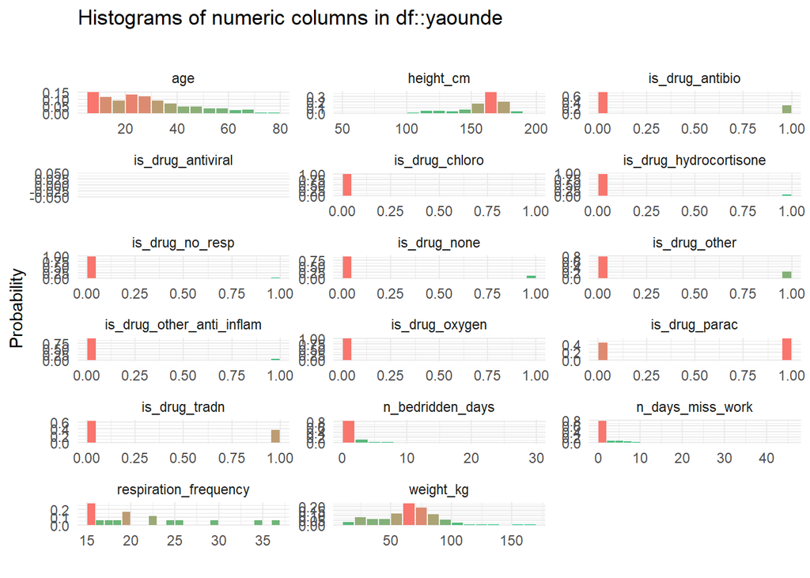

```r
# INSPECT NUMERIC VARIABLES

yao_num_summary <- inspect_num(yaounde)

show_plot(yao_num_summary)
```

R DATA CLASSES VS VARIABLE TYPES

INSPECT CAT AND INSPECT NUM

**What is a variable?**

A variable is something we can observe or study, a feature of individual units (e.g., humans) in our data.

# Variable Types

When conducting descriptive analysis, the method you choose will depend on the *type* of data you’re analyzing. At the most basic level, variables can be described as numerical or categorical.

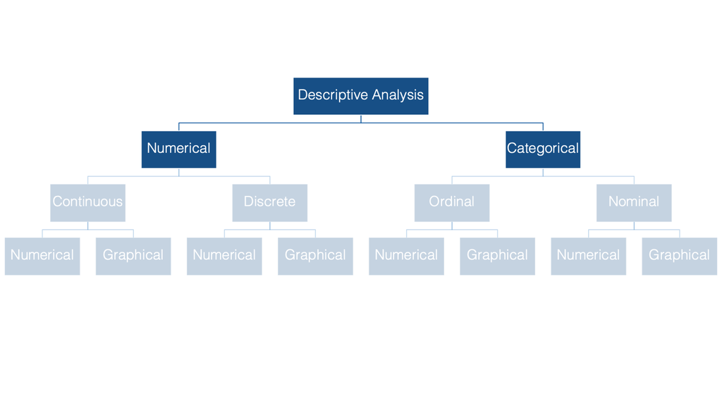

Numeric variables can then be further divided into **continuous** and **discrete** - the distinction being whether the variable can take on a continuum of values (e.g., height or weight), or only set of certain values (e.g., age or year).

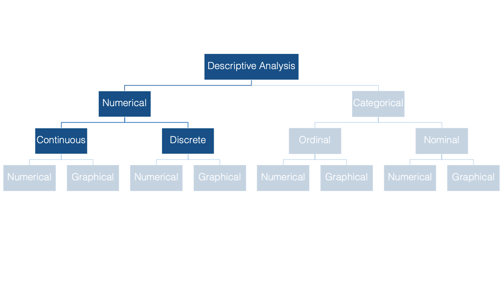

Categorical variables can be subdivided into **ordinal** or **nominal** variables - depending on whether or not the categories can logically be ordered in a meaningful way.

Some examples of categorical variables seen in our `yaounde` data frame are: `sex`, `highest_education`, and `age_category`. In fact, most of the variables in this dataset are categorical.

```r
head(yaounde)
```

| id | date_surveyed | age | age_category | age_category_3 | sex | highest_education | occupation | weight_kg | height_cm | is_smoker | is_pregnant | is_medicated | neighborhood | household_with_children | breadwinner | source_of_revenue | has_contact_covid | igg_result | igm_result | symptoms | symp_fever | symp_headache | symp_cough | symp_rhinitis | symp_sneezing | symp_fatigue | symp_muscle_pain | symp_nausea_or_vomiting | symp_diarrhoea | … |
| --- | --- | --- | --- | --- | --- | --- | --- | --- | --- | --- | --- | --- | --- | --- | --- | --- | --- | --- | --- | --- | --- | --- | --- | --- | --- | --- | --- | --- | --- | --- |
| BRIQUETERIE_000_0001 | 2020-10-22 | 45 | 45 - 64 | Adult | Female | Secondary | Informal worker | 95 | 169 | Non-smoker | No | Yes | Briqueterie | No children | No response | Other | Recent COVID contact | Negative | Negative | Muscle pain | No | No | No | No | No | No | Yes | No | No | … |
| BRIQUETERIE_000_0002 | 2020-10-24 | 55 | 45 - 64 | Adult | Male | University | Salaried worker | 96 | 185 | Ex-smoker | NA | No | Briqueterie | No children | Other family | Regular, Formal--Regular, Commerce | No COVID contact | Positive | Negative | No symptoms | No | No | No | No | No | No | No | No | No | … |
| BRIQUETERIE_000_0003 | 2020-10-24 | 23 | 15 - 29 | Adult | Male | University | Student | 74 | 180 | Smoker | NA | Yes | Briqueterie | No children | No response | Other | No COVID contact | Negative | Negative | No symptoms | No | No | No | No | No | No | No | No | No | … |
| BRIQUETERIE_002_0001 | 2020-10-22 | 20 | 15 - 29 | Adult | Female | Secondary | Student | 70 | 164 | Non-smoker | No | No | Briqueterie | With children | Mother | Irregular, Commerce | No COVID contact | Positive | Negative | Rhinitis--Sneezing--Anosmia or ageusia | No | No | No | Yes | Yes | No | No | No | No | … |
| BRIQUETERIE_002_0002 | 2020-10-22 | 55 | 45 - 64 | Adult | Female | Primary | Trader--Farmer | 67 | 147 | Non-smoker | No | No | Briqueterie | With children | Mother | Regular, Informal--Irregular, Commerce--Other | No COVID contact | Positive | Negative | No symptoms | No | No | No | No | No | No | No | No | No | … |
| BRIQUETERIE_002_0003 | 2020-10-25 | 17 | 15 - 29 | Child | Female | Secondary | Student | 65 | 162 | Non-smoker | No | No | Briqueterie | With children | No response | Irregular, Commerce | No COVID contact | Negative | Negative | Fever--Cough--Rhinitis--Nausea or vomiting--Diarrhoea | Yes | No | Yes | Yes | No | No | No | Yes | Yes | … |

Can you identify which variables are numeric? Of those, which are continuous and which are discrete? The `glimpse()` function can help us get a better look at this.

```r
glimpse(yaounde)
```

```
Rows: 971
Columns: 53
$ id                        <chr> "BRIQUETERIE_000_0001", "BRIQUETERIE_000_000…
$ date_surveyed             <date> 2020-10-22, 2020-10-24, 2020-10-24, 2020-10…
$ age                       <dbl> 45, 55, 23, 20, 55, 17, 13, 28, 30, 13, 62, …
$ age_category              <chr> "45 - 64", "45 - 64", "15 - 29", "15 - 29", …
$ age_category_3            <chr> "Adult", "Adult", "Adult", "Adult", "Adult",…
$ sex                       <chr> "Female", "Male", "Male", "Female", "Female"…
$ highest_education         <chr> "Secondary", "University", "University", "Se…
$ occupation                <chr> "Informal worker", "Salaried worker", "Stude…
$ weight_kg                 <dbl> 95, 96, 74, 70, 67, 65, 65, 62, 73, 56, 53, …
$ height_cm                 <dbl> 169, 185, 180, 164, 147, 162, 150, 173, 170,…
$ is_smoker                 <chr> "Non-smoker", "Ex-smoker", "Smoker", "Non-sm…
$ is_pregnant               <chr> "No", NA, NA, "No", "No", "No", "No", NA, NA…
$ is_medicated              <chr> "Yes", "No", "Yes", "No", "No", "No", "No", …
```

[output cut: 40 more lines]

SIDE NOTE: DISCRETE NUMERIC DATA PRACTICALLY ORDINAL? – there are examples that can be considered both numerical and ordinal (e.g., number of children?).

**Review of the Main Data Classes in R**

R data classes correspond to different variable types:

Variable Type

R Data Class

Continuous

`numeric`, specifically `double`

Discrete

`numeric`, specifically `integer`

Ordinal

`factor` (ordered)

Nominal

`character`

Binary

`numeric`, specifically `integer` with 2 values (e.g., 0 and 1),

- `logical` a.k.a. Boolean (`TRUE` or `FALSE`)
- `character` with 2 values (e.g., “success” and “failure”)
- `factor` with 2 values, (e.g., “low” and “high”)

**Practice**

**Identifying Variable Types and R Data classes**

For each of the following variables, identify (1) the variable type (categorical or numerical), (2) its subtype (e.g., nominal, ordinal, discrete, continuous), and (3) the corresponding R data class.

1. `age`
2. `highest_education`
3. `is_smoker`
4. `date_surveyed`
5. `weight_kg`
6. `igg_result`

# Methods of Describing Distributions

Variables in a dataset are described by distributions rather than single values.

Remember, we are ultimately aiming to make inferences about populations rather than individuals, so we are not just interested in describing one particular person, but the population as a whole.

How do we describe distributions? One option is to display all the data, but that is not necessarily useful or practical.

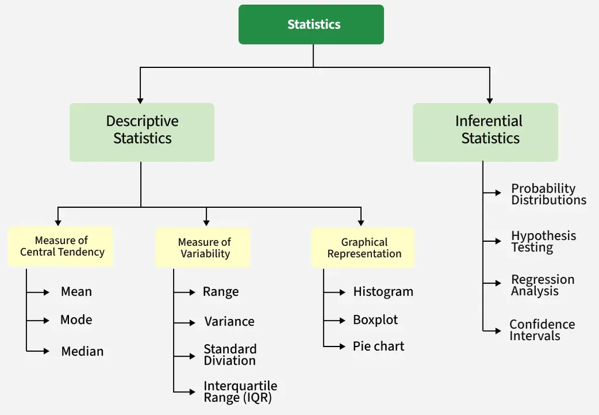

Descriptive analysis of numerical variables can be measured by two different methods: **graphical** or **numerical**. The best way to describe a distribution depends on the type of variable being summarized and its distribution.

**How do we describe distributions?**

There are both **numerical** and **graphical** methods we can use to perform descriptive analysis for all types and subtypes of variables.

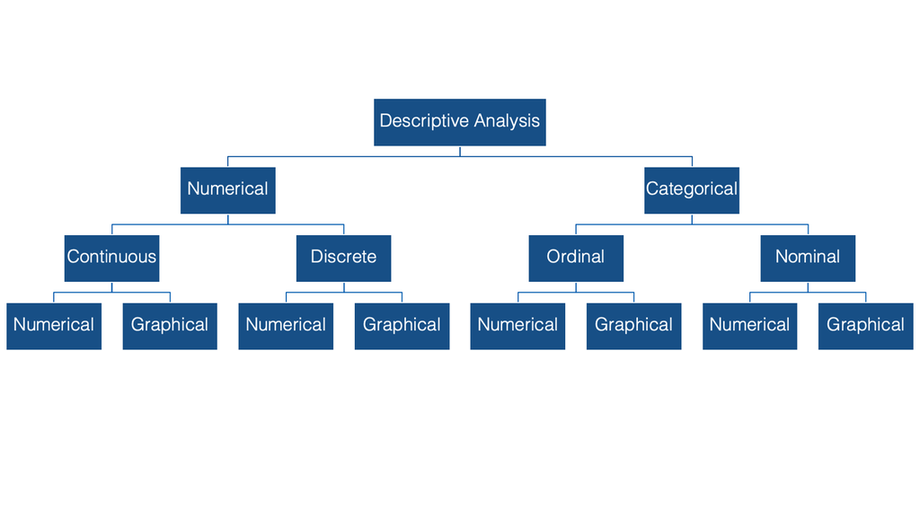

**Practice**

**Identifying Variable Types**

For the four variables below, select whether it is numerical or categorical. If categorical, specify if it’s ordinal or nominal. If numerical, classify as discrete or continuous.

1. Stress level, responses are “high”, “medium”, “low”.
2. Age in years
3. Height in centimeters
4. Country name

**Practice**

**Identifying Variable Types**

If I measure age (in years) in a sample of 10,000 women, what type of variable would this be classified as?

1. Continuous
2. Binary
3. Nominal
4. Discrete

# Categorical Variables

We’ll start by describing categorical variables, both numerically and graphically. As a reminder, categorical variables are variables whose values fit into distinct categories.

## Numerical Descriptions of Categorical Variables

We’ll begin our discussion of descriptive statistics in the categorical half of our flow chart. Specifically, we’ll start by numerically describing categorical variables.

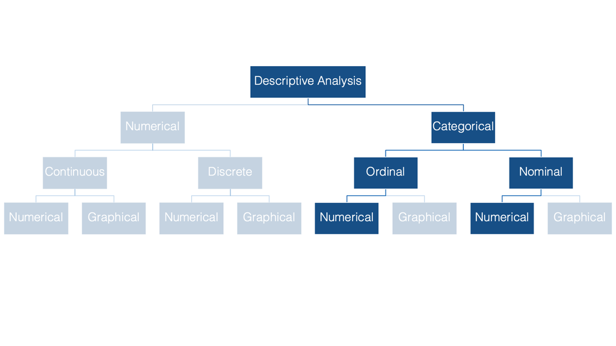

The two most common numerical descriptions of categorical variables are probably the **frequency count** (you will often hear this referred to as simply the frequency, the count, or the n) and the **proportion or percentage** (the percentage is just the proportion multiplied by 100).

Using the `tabyl()` function from the `{janitor}` package, we can make frequency tables displaying the frequencies and percentages of categorical variable(s).

```r
# Make a frequency table of the `is_smoker` variable.
yaounde %>% tabyl(is_smoker)
```

```
  is_smoker   n     percent valid_percent
  Ex-smoker  71 0.073120494    0.07327141
 Non-smoker 859 0.884654995    0.88648091
     Smoker  39 0.040164779    0.04024768
       <NA>   2 0.002059732            NA
```

We can also use the `tabyl()` function to create 2-way frequency tables.

```r
# Create a summary data frame of two categorical variables
yaounde %>%
  tabyl(is_smoker, sex)
```

```
  is_smoker Female Male
  Ex-smoker     16   55
 Non-smoker    528  331
     Smoker      4   35
       <NA>      1    1
```

```r
yaounde %>%
  tabyl(is_smoker, sex) %>%
  adorn_percentages("row")
```

```
  is_smoker    Female      Male
  Ex-smoker 0.2253521 0.7746479
 Non-smoker 0.6146682 0.3853318
     Smoker 0.1025641 0.8974359
       <NA> 0.5000000 0.5000000
```

**Practice**

**Frequency Tables**

Use the `tabyl()` function from the `{janitor}` package to answer the following:

1. Create a frequency table of `has_contact_covid`.
2. Create a two-way frequency table between `has_contact_covid` and `igg_result`.
3. Use `adorn_percentages("row")` to display row-wise proportions in the table created above.

## Graphical Descriptions of Categorical Variables

A **bar chart** is the simplest way to graphically describe the distribution of a categorical variable.

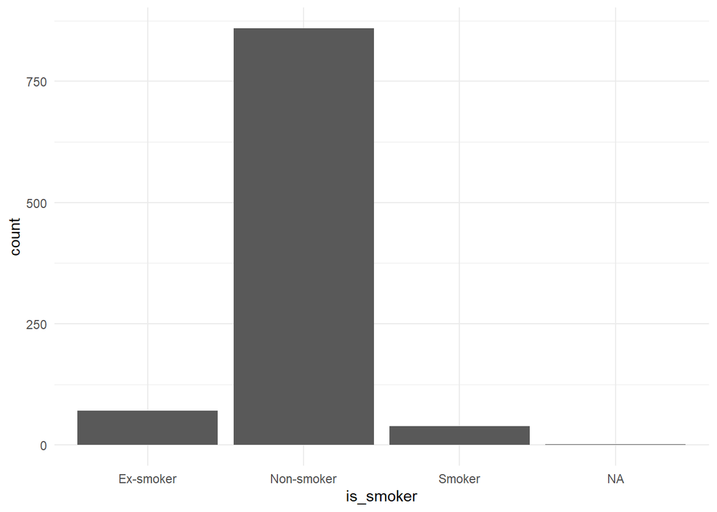

```r
ggplot(yaounde) +
  geom_bar(aes(x = is_smoker))
```

A **stacked bar chart** can help us visualize the distribution of two categorical variables.

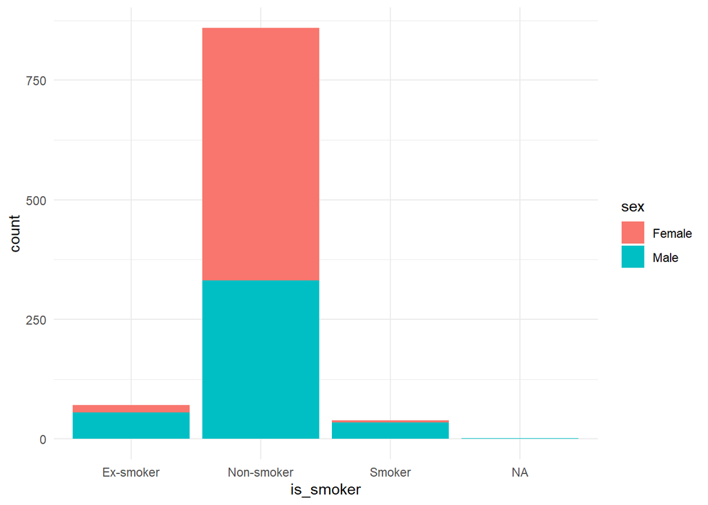

```r
ggplot(yaounde) +
  geom_bar(aes(x = is_smoker, fill = sex))
```

A **percent-stacked bar chart** visualizes them as proportions rather than counts.

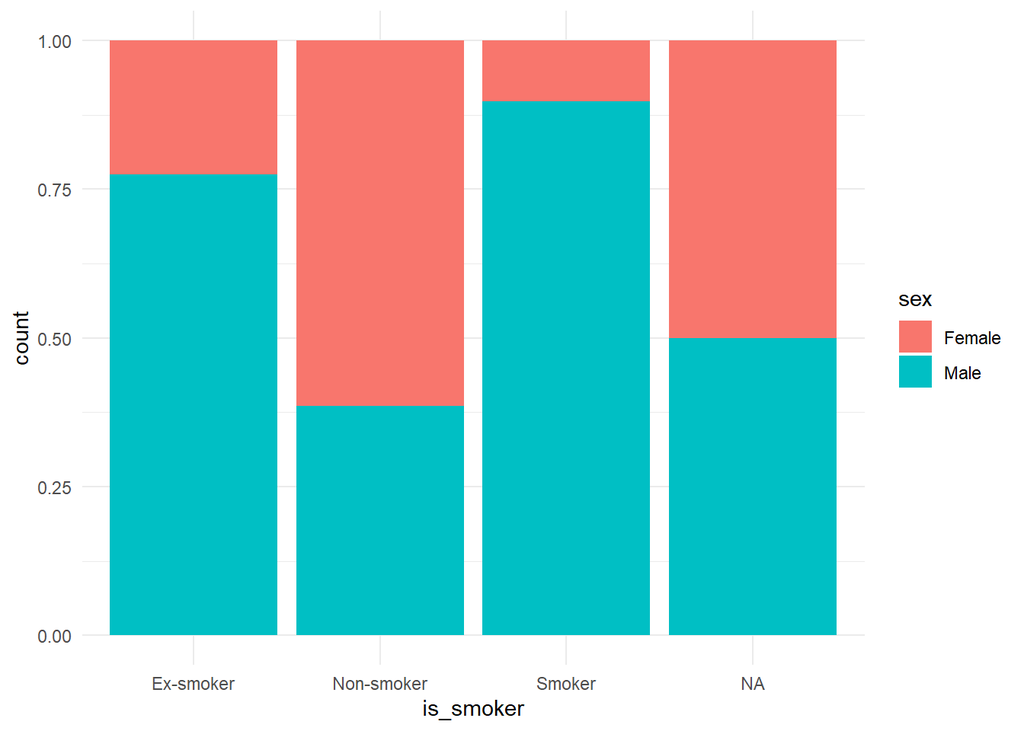

```r
ggplot(yaounde) +
  geom_bar(aes(x = is_smoker, fill = sex),
    position = "fill"
  )
```

**BAR CHART OF ORDINAL VARIABLE WITH ORDERED CATEGORIES**

DEFAULT GGPLOT ORDERING IS ALPHABETICAL

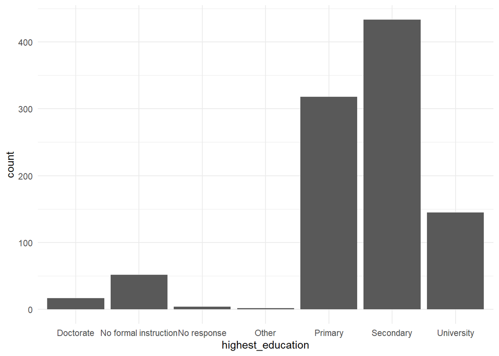

```r
ggplot(yaounde) +
  geom_bar(aes(x = highest_education))
```

REORDER THE FACTOR LEVELS

```r
yaounde <- yaounde %>%
  mutate(
    highest_education =
      factor(highest_education,
        levels = c(
          "No formal instruction",
          "Primary",
          "Secondary",
          "University",
          "Doctorate",
          "No response"
        )
      )
  )
```

PLOT AGAIN –

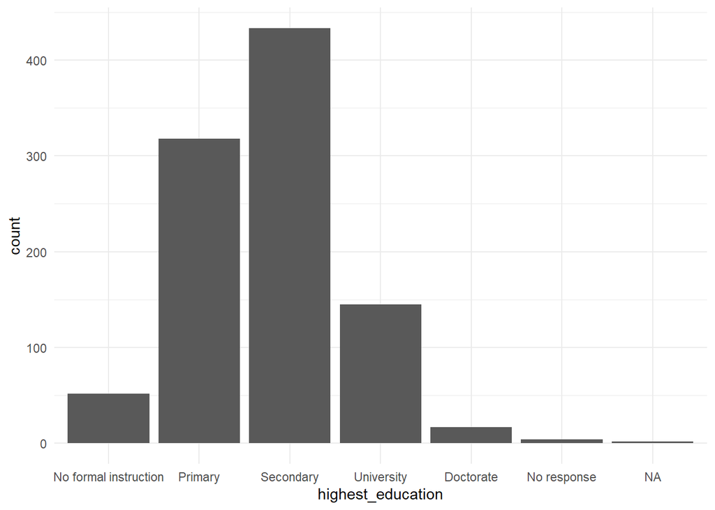

```r
ggplot(yaounde) +
  geom_bar(aes(x = highest_education))
```

SRATIFICATION – COMPARE DISTRIBUTIONS BETWEEN CATEGORIES

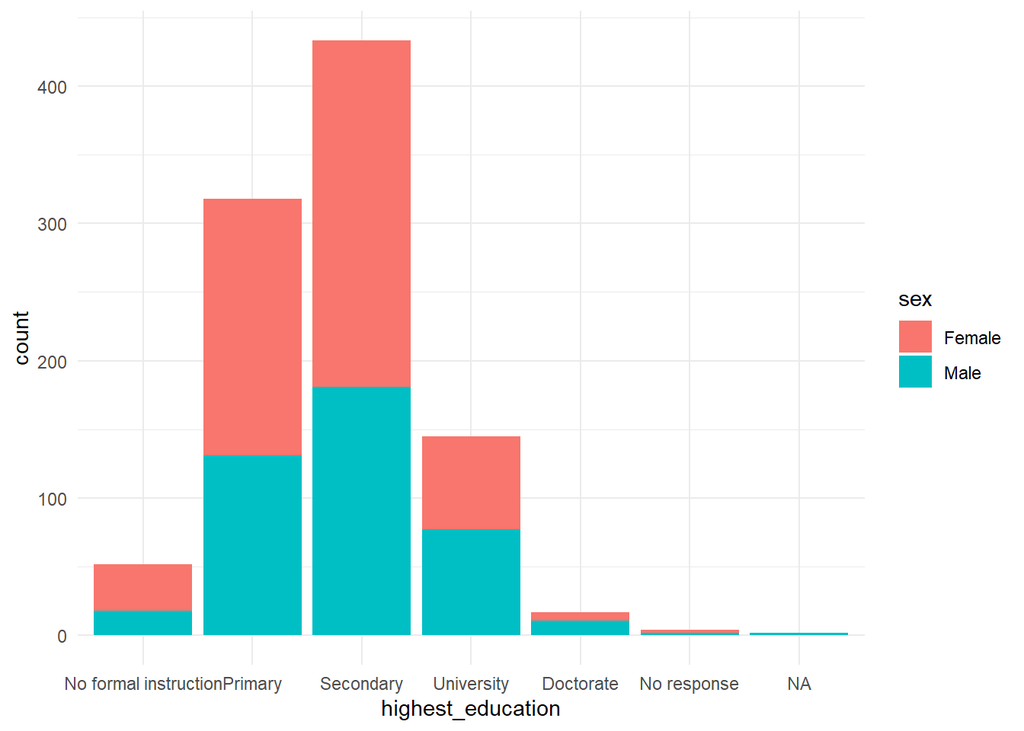

```r
ggplot(yaounde) +
  geom_bar(aes(x = highest_education, fill = sex))
```

PROPORTIONS RATHER THAN COUNTS –

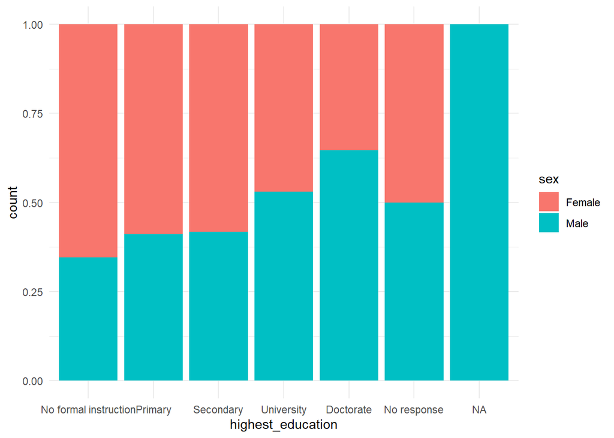

```r
ggplot(yaounde) +
  geom_bar(aes(x = highest_education, fill = sex),
    position = "fill"
  )
```

SWAP THE STRATIFICATION HIERARCHY –

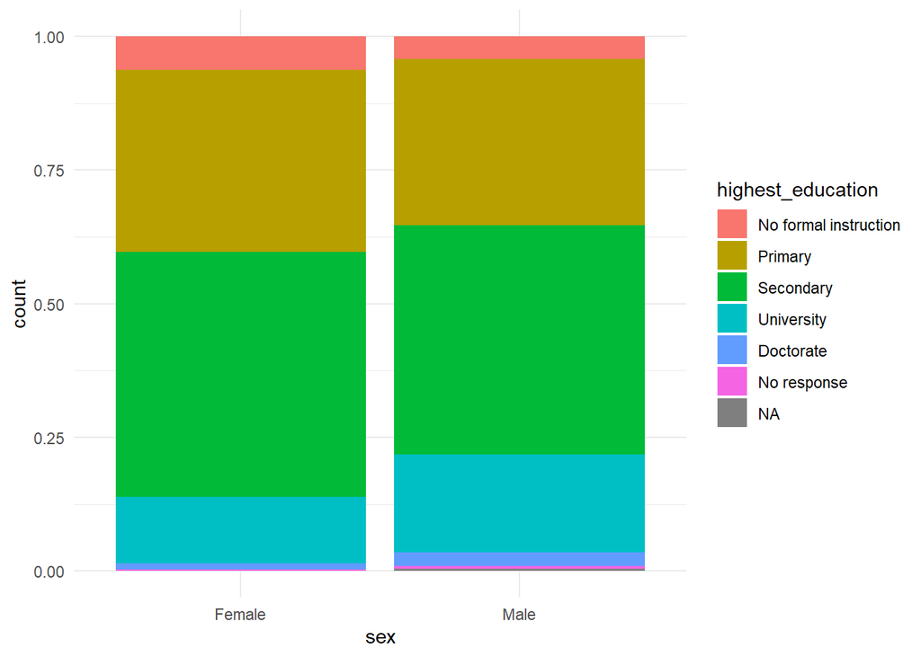

```r
ggplot(yaounde) +
  geom_bar(aes(x = sex, fill = highest_education),
    position = "fill"
  )
```

**Practice**

**Bar Charts**

Use `ggplot()` to create the following charts:

1. Plot a bar chart showing the distribution of `age_category_3`, colored by `is_smoker`.
2. Create a percent-stacked bar chart showing the same variables.
3. Reorder the `age_category_3` factor so that the categories appear in the logical order (youngest to oldest) and then plot again.

# Numerical Variables

## Graphical Summaries of Numerical Variables

Visualizations are essential in public health to communicate findings clearly. Two common plots for numerical data are **histograms** and **boxplots**.

### Histograms

A histogram shows how often values fall into specified bins or intervals. This is useful for checking skewness and identifying outliers.

A histogram visualizes the distribution of a numerical value as follows:

1. We first cut up the x-axis into a series of *bins*, where each bin represents a range of values.
2. For each bin, we count the number of observations that fall in the range corresponding to that bin.
3. Then for each bin, we draw a bar whose length marks the corresponding count.

**Tip**

The function for creating histogram in `{ggplot2}` is **`geom_histogram()`**. We can use `fill` and `color` to enhance the appearance of the bars.

Now let’s use {ggplot2} to plot the distribution of heights, which is recorded in the `height_cm` column.

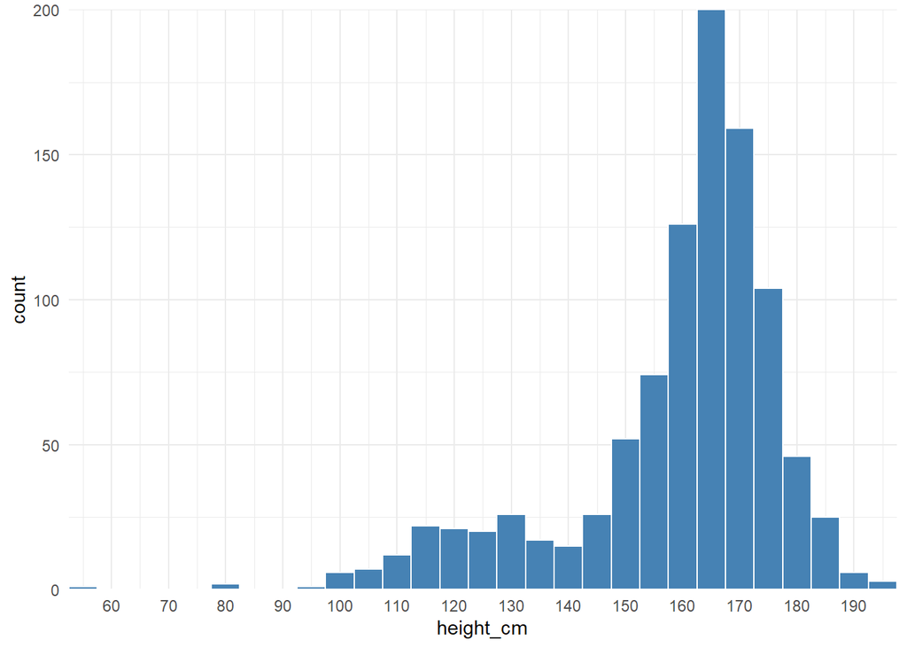

```r
# Histogram showing the distribution of height_cm
ggplot(
  data = yaounde,
  mapping = aes(x = height_cm)
) +
  geom_histogram(
    color = "white",
    fill = "steelblue", binwidth = 5
  ) +
  scale_x_continuous(
    breaks = scales::pretty_breaks(n = 12),
    expand = c(0, 0)
  ) +
  scale_y_continuous(expand = c(0, 0))
```

What if we filter out the children and plot the histogram again?

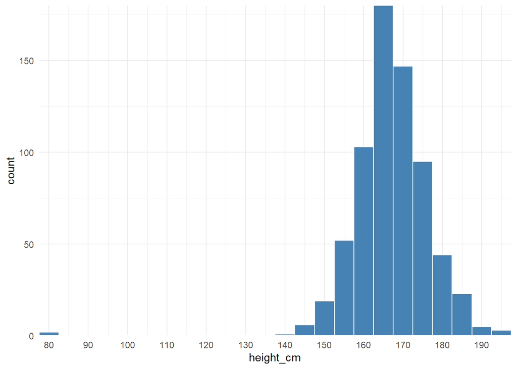

```r
# Create new df of only adults
yao_adults <- yaounde %>% filter(age_category_3 != "Child")

# Define base ggplot layers
yao_adults_height <- ggplot(
  data = yao_adults,
  mapping = aes(x = height_cm)
) +
  scale_x_continuous(
    breaks = scales::pretty_breaks(n = 12),
    expand = c(0, 0)
  ) +
  scale_y_continuous(expand = c(0, 0))

yao_adults_height +
  geom_histogram(
    color = "white",
    fill = "steelblue",
    binwidth = 5
  )
```

- We have a much more normal distribution, which is what you would expect for a variable like height or weight.
- Note the **outliers**: 2 adults under 140 cm.

We can vary the number of bins to get more or less detail from the histogram.

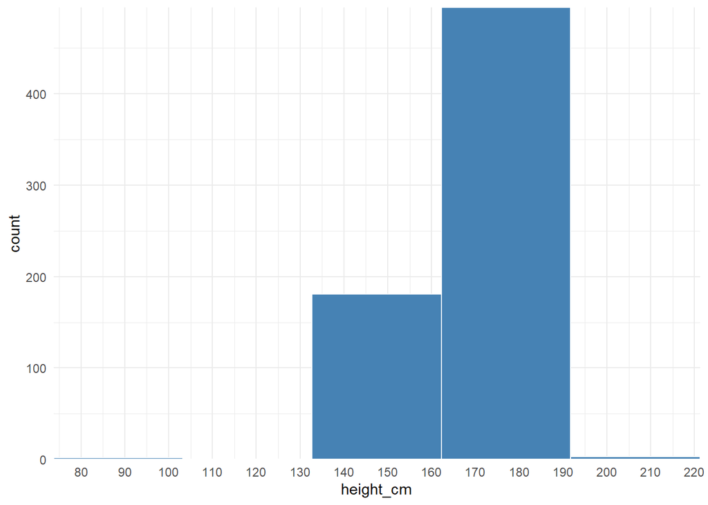

```r
# Try different numbers of bins

yao_adults_height +
  geom_histogram(
    bins = 5,
    color = "white",
    fill = "steelblue"
  )
```

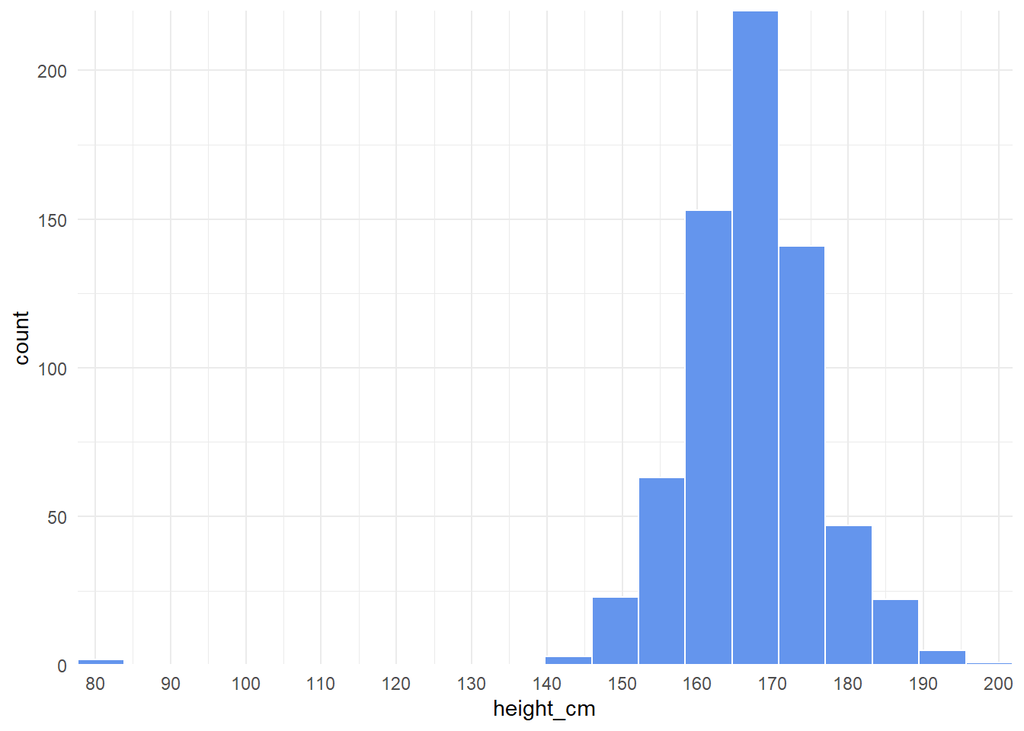

```r
yao_adults_height +
  geom_histogram(
    bins = 20,
    color = "white",
    fill = "cornflowerblue"
  )
```

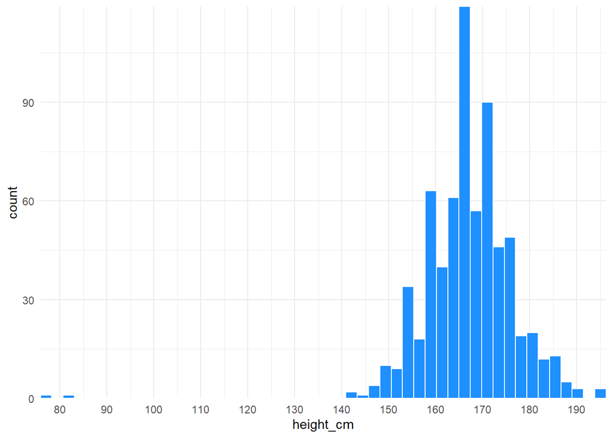

```r
yao_adults_height +
  geom_histogram(
    bins = 50,
    color = "white",
    fill = "dodgerblue"
  )
```

- By using smaller bins, we get a more accurate and precise estimate of how heights are distributed.

### Density Curves

- We can also represent continuous distributions with a smoothed curve, which is a useful alternative to the histogram.
- We can use a curve to approximate the histogram by plotting it on top of the bars.

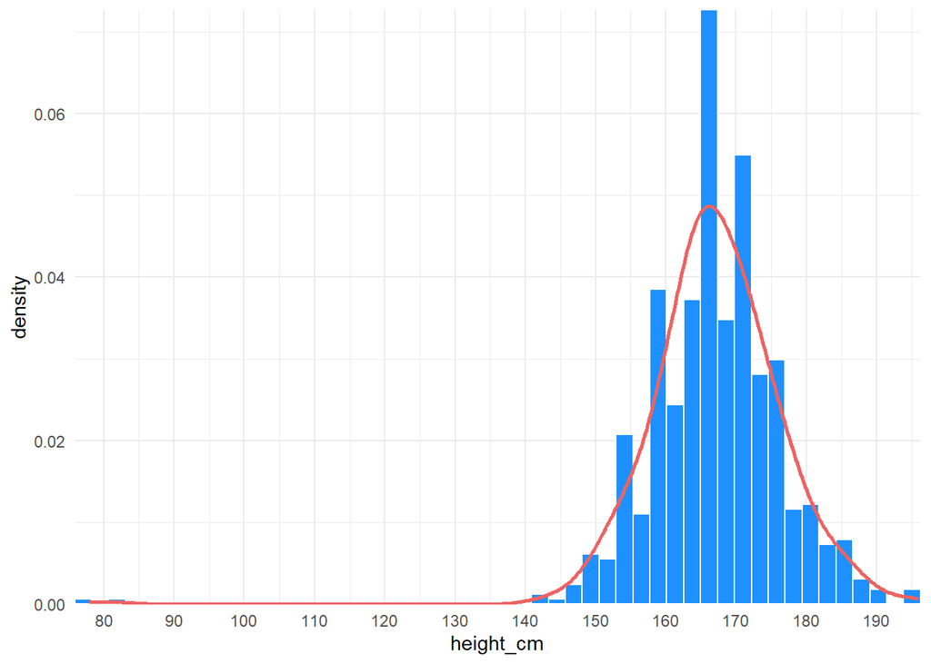

```r
yao_adults_height +
  geom_histogram(
    bins = 50,
    color = "white",
    fill = "dodgerblue",
    mapping = aes(y = after_stat(density))
  ) +
  geom_density(
    color = "indianred2",
    alpha = 0.25,
    linewidth = 1,
    bw = 3
  )
```

The curve tells us the same thing that the histogram tells us:

The curve has a few advantages over the histogram.

- For example, we don’t have any values in the second-last bin, but we can use the curve to calculate the probability.
- Furthermore, the curve is not limited by the width of the bins - we can use calculus to determine the probability of measuring someone between 172.5 and 183.7 cm, without having to round to the nearest bin size.
- Lastly, if we have very few measurements, we can still approximate a curve using the mean and standard deviation of the few data points that we have.

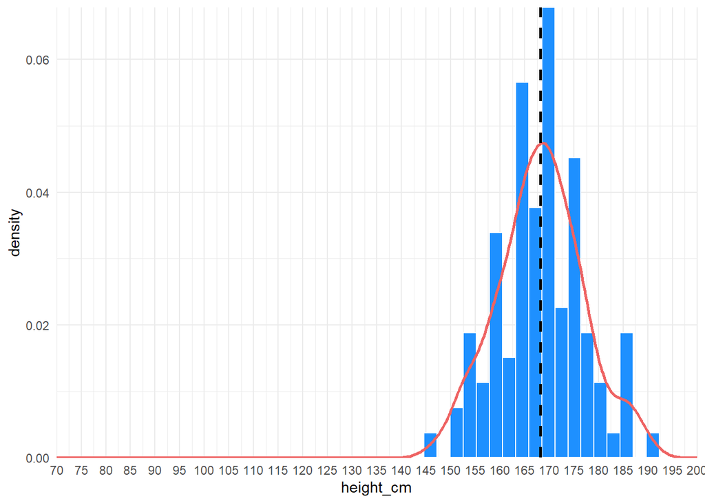

```r
ggplot(
  data = sample_n(yao_adults, 100),
  mapping = aes(x = height_cm)
) +
  geom_histogram(
    bins = 50,
    color = "white",
    fill = "dodgerblue",
    mapping = aes(y = after_stat(density))
  ) +
  geom_density(
    color = "indianred2",
    alpha = 0.25,
    linewidth = 1
  ) +
  scale_x_continuous(
    breaks = scales::pretty_breaks(n = 24),
    expand = c(0, 0), limits = c(70 , 200)
  ) +
  scale_y_continuous(expand = c(0, 0)) +
  geom_vline(aes(xintercept = mean(height_cm)),
    linetype = "dashed", linewidth = 1
  )
```

Try rerunning the code; each time will use a different random sample of 100 individuals from the dataset.

**Stratifying kernel density plots**

The **`geom_density()`** function draws kernel density estimates, which is a smoothed version of a histogram. This is a useful alternative to the histogram for continuous data.

By plotting separate overlapping curves for each sex, we can graphically describe how the distribution of heights varies between sexes.

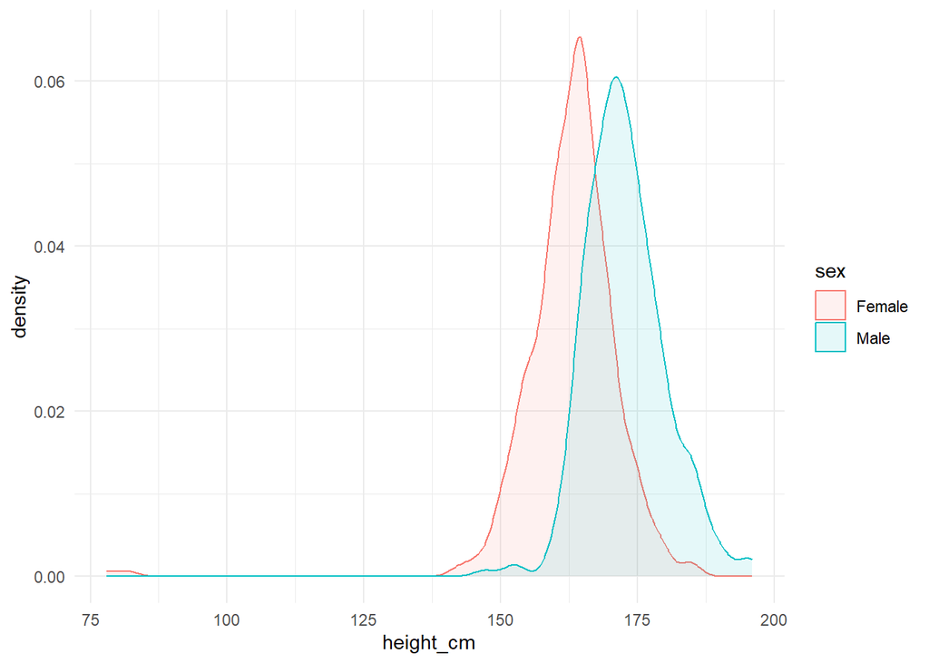

```r
ggplot(yao_adults, aes(height_cm,
  colour = sex,
  fill = sex
)) +
  geom_density(alpha = 0.1)
```

**Practice**

**Plotting Histograms**

- Plot a histogram showing the distribution of `n_bedridden_days` in `yaounde`.

Make notes on these key questions:

1. What are the smallest and largest values?
2. What are frequent and infrequent values?

**Practice**

**Density Plot of weight by sex**

- Plot a kernel density plot showing the distribution of weight for each sex in `yaounde`.

Make notes on these key questions:

1. What is the “center” or “most typical” value for each sex? How similar are the distributions?
2. How do the values spread out? Is there a clear peak at the center?

### Boxplots

Let’s start with a simple boxplot by mapping one numeric variable from `yaounde`, the height of patients (**`height_cm`**).

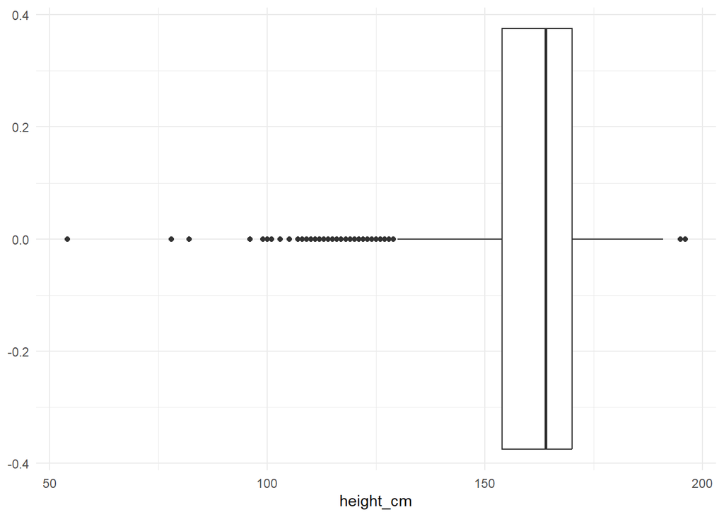

```r
# Simple boxplot of height_cm
ggplot(
  data = yaounde,
  mapping = aes(x = height_cm)
) +
  geom_boxplot()
```

A boxplot consists of two parts:

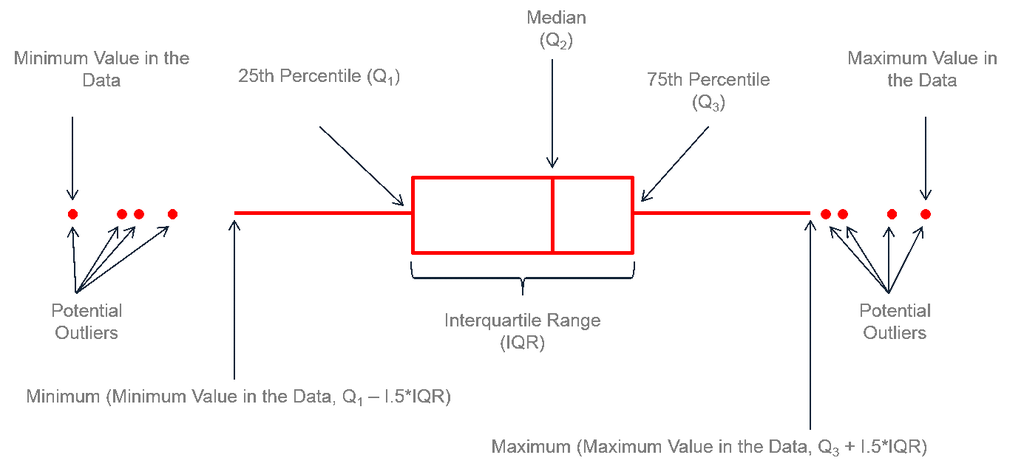

1. **Box** — Extends from the first to the third quartile (Q1 to Q3) with a line in the middle that represents the *median*. The range of values between Q1 and Q3 is also known as an *Interquartile range (IQR)*.
2. **Whiskers** — Lines extending from both ends of the box indicate variability outside Q1 and Q3. The minimum/maximum whisker values are calculated as $Q1 - 1.5 \times IQR$ to $Q3 + 1.5 \times IQR$ . Everything outside is represented as an *outlier* using dots or other markers.

**Tip**

The function for creating boxplots in {ggplot2} is **`geom_boxplot()`**. We can use `fill` argument inside the `aes()` function to color the boxes by a categorical variable.

To create a side-by-side boxplot (which is what we usually want), we need to add a categorical variable.

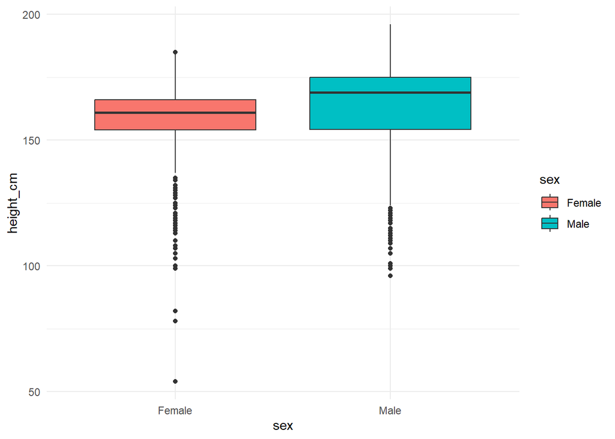

```r
ggplot(
  yaounde,
  aes(
    x = sex,
    y = height_cm,
    fill = sex
  )
) +
  geom_boxplot()
```

We can clearly see that there are notable differences in median height (central line of each box) between sexes. However, there is a lot of overlap between the range of values.

Boxplots have the limitation that they summarize the data into just five numbers: the 1st quartile, the median (the 2nd quartile), the 3rd quartile, and the upper and lower whiskers. By doing this, we might miss important characteristics of the data.

One way to add more detail is to plot the individual observations as a **layer of points** on top of the boxplot with the **`geom_jitter()`** function.

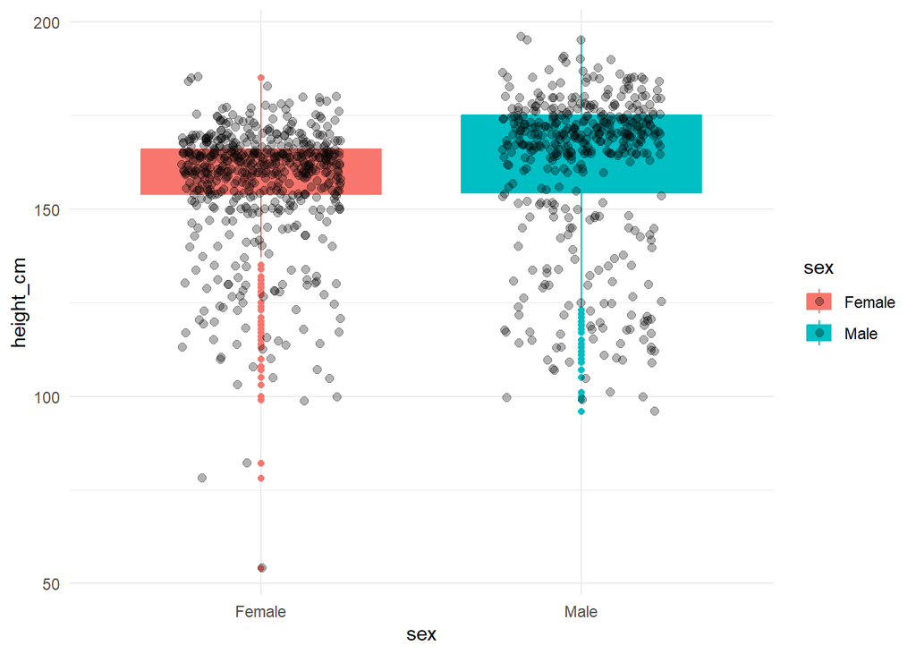

```r
ggplot(
  yaounde,
  aes(
    x = sex,
    y = height_cm,
    fill = sex
  )
) +
  geom_boxplot(aes(color = sex)) +
  geom_jitter(
    size = 2,
    width = 0.25,
    alpha = 0.3
  )
```

Here, additional patterns become visible, such as variations and potential outliers within each sex group.

**VIOLIN PLOTS**